[figure not shown]

# 项目反应理论及其在洋葱数学中的应用

姬弘飞  
11月1日

### 项目反应理论（Item Response Theory）

- 测试是对被试某一方面或某几方面能力的估计
- 用户在测试时能力是一定的、独立于测试的
- 测试中，不同题目（项目）对不同能力的用户，意义不同
- 测试需要找到基于之前被试的能力估计值意义最大的项目，并根据用户对该项目的反应更新对其能力的估计

### 三个关键过程

- 项目参数估计
- 用户能力估计
- 用户能力估计更新
  - 选取项目
  - 收敛

### 项目参数估计

- 项目区分度
- 项目难度
- 项目猜测系数

使用Logistic回归，三参数模型：

$$P(\theta)=c + (1-c)\frac{1}{1+e^{-a(\theta-b))}}$$

其中，

- $\theta$ 是能力估计标准值
- $a$ 是项目区分度
- $b$ 是项目难度
- $c$ 是项目猜测因子

当$c$为0时，转变为双参数模型：

$$P(\theta)= \frac{1}{1+e^{-a(\theta-b))}}$$

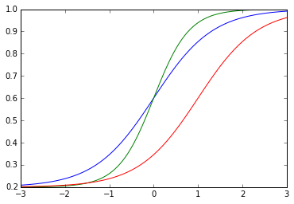

```python
# This magic command could import numpy as np
%pylab inline

a = 1.5
a2 = 2.5
b = 0.0
b2 = 1.0
c = 0.2

def item_model(x):
    return c + (1-c) * (1 / (1 + np.exp(-a * (x - b))))

def item_model_a(x):
    return c + (1-c) * (1 / (1 + np.exp(-a2 * (x - b))))

def item_model_b(x):
    return c + (1-c) * (1 / (1 + np.exp(-a * (x - b2))))

x = np.linspace(-3,3,100)
y = np.apply_along_axis(item_model, 0, x)
y2 = np.apply_along_axis(item_model_a, 0, x)
y3 = np.apply_along_axis(item_model_b, 0, x)
pylab.plot(x, y)
pylab.plot(x, y2)
pylab.plot(x, y3)
pylab.show()
```

### 项目参数的估计

$c$确定，用最小二乘法拟合

原始数据结构：

```python
from pymongo import MongoClient
import pprint

db_client = MongoClient("mongodb://localhost:27017")
db = db_client['yangcong']

problem_histories = db['problemhistories']

sample_doc = problem_histories.find_one()

# Output pretty json
pp = pprint.PrettyPrinter(indent=4)
pp.pprint(sample_doc)
```

```
{   u'__v': 0,
    u'_id': ObjectId('54d7ac302b11f4174d392257'),
    u'activity': ObjectId('54c70a8ebeef782425f442e7'),
    u'chapter': ObjectId('538fe05c76cb8a0068b14031'),
    u'createdBy': datetime.datetime(2015, 2, 8, 18, 15, 50, 629000),
    u'from': u'pc',
    u'isCorrect': True,
    u'problem': ObjectId('54cc509f80e029f750a75fe8'),
    u'rooms': [],
    u'task': ObjectId('53959b4db8233b3704e37def'),
    u'topic': ObjectId('54c708798bac81fccbd4bb6b'),
    u'user': ObjectId('539ad7581d74e34003940983'),
    u'userAnswer': [u'54cc50ba80e029f750a75fec']}
```

以章节为单位整合数据。

1. 选取全章至少完成30道题目的用户（$U$）
2. 计算每个用户的正确率
3. 找到该章节中的所有题目
4. 对每一道题目做如下操作：
   - 找到$U$中做过该题目的所有用户$u$
   - 以$u$为样本，计算$u$中每一个用户的Z分数
   - 找到$u$中每一个用户**首次完成**该题目的答案，正确记为1，错误记为0

整合后的数据（示例）：

```python
from pymongo import MongoClient
import pprint

db_client = MongoClient("mongodb://localhost:27017")
db = db_client['yangcong']

origin_data = db['problemorigin']

sample_doc = origin_data.find_one()

# Output pretty json
pp = pprint.PrettyPrinter(indent=2)
pp.pprint(sample_doc)
```

```
{ u'_id': ObjectId('56346e6112ab3b59d5f55455'),
  u'problemId': ObjectId('54d325aa9ca3a7f10f5e9f09'),
  u'response': { u'53c49d1618b3356130f6d163': { u'response': 1,
                                                u'zscore': 0.41386491944184595},
                 u'54041e65508af566725291a6': { u'response': 1,
                                                u'zscore': -0.04210229218585722},
                 u'540959f5c34d6dc35117e5e6': { u'response': 1,
                                                u'zscore': -0.7513846213845073},
                 u'54143e05a1e7ee383a4e530f': { u'response': 0,
                                                u'zscore': -1.1163551402925505},
                 u'54253c82ae4df63d015646a3': { u'response': 1,
                                                u'zscore': -1.2580148565264002},
                 u'543753766593967e141c495a': { u'response': 1,
                                                u'zscore': 1.3508102024067898},
                 u'54752606c0069d5b7d242a3a': { u'response': 1,
                                                u'zscore': 1.3475120670604774},
                 u'5493d22ef790d0094919e381': { u'response': 1,
                                                u'zscore': 0.8576730054261442},
                 u'54a950ea300077a92bcdae83': { u'response': 1,
                                                u'zscore': 0.801191905663229},
                 u'54b66bf2f67c531d5fef8b69': { u'response': 1,
                                                u'zscore': 0.8421977546072644},
                 u'54b6731d4b8657245fd71d38': { u'response': 1,
                                                u'zscore': 0.7109344664114109},
                 u'54b74c70dac6ecf05e49f1ff': { u'response': 0,
                                                u'zscore': -0.9220390163796712},
                 u'54b85e901a26ac923e6e1c7e': { u'response': 1,
                                                u'zscore': -0.055919480417000136},
                 u'54b901f0be42c9d95e94635d': { u'response': 1,
                                                u'zscore': 1.127044404295434},
                 u'54ba555c5b3472d80eee1d24': { u'response': 1,
                                                u'zscore': 0.4072566989834734},
                 u'54ba710068b6dcf00e6f35dc': { u'response': 1,
                                                u'zscore': -0.48793689911072297},
                 u'54bb5aebeb7d37d318987339': { u'response': 1,
                                                u'zscore': -0.8755907435483263},
                 u'54c0df3e591eff89631d459a': { u'response': 1,
                                                u'zscore': 1.3349553108022276},
                 u'54c76fae5cd523ac20db18ae': { u'response': 1,
                                                u'zscore': -0.5356905608785528},
```

[output cut: 187 more lines]

```
                                                u'zscore': -0.7108542025731558},
                 u'55dbdb25105462a35cb35de9': { u'response': 1,
                                                u'zscore': -0.21580408709164903},
                 u'55dbdb25105462a35cb35df5': { u'response': 1,
                                                u'zscore': 0.9306277592865766},
                 u'55dd37a0c36a804b0630bb76': { u'response': 1,
                                                u'zscore': 0.897466507531835},
                 u'55e2ad003018a1b36cdbec4e': { u'response': 1,
                                                u'zscore': -0.4600722361779188},
                 u'55f10abeac3df58e3add17e8': { u'response': 1,
                                                u'zscore': 0.01389368117193071},
                 u'55fe1ca05dc3d48675e57fd3': { u'response': 0,
                                                u'zscore': -0.6679396414787838},
                 u'5603ddcd5189a8c523f81632': { u'response': 1,
                                                u'zscore': 1.4777884132398214}}}
```

根据这些基于题目的数据，使用最小二乘法，拟合三参数模型

继上例，设$c$为0.15：

```python
import numpy as np
from scipy import optimize

problem_id = sample_doc['problemId']
responses = sample_doc['response']

# guessing index c
c = 0.15

# transform data structure
theta = []
res = []
doing_right = [[0.0, 0], [0.0, 0], [0.0, 0], [0.0, 0], [0.0, 0], [0.0, 0], [0.0, 0]]
for each in responses:
    theta.append(responses[each]['zscore'])
    res.append(responses[each]['response'])
    index = int(responses[each]['zscore']) + 3
    if responses[each]['response'] == 1:
        doing_right[index][0] += 1
    doing_right[index][1] += 1

# discrimination and difficulty a/b
def item_characters(x, a, b):
    return c + (1 - c) * (1 / np.exp(-a * (x - b)))

initialEstimation = np.array([0.0, 0.0])
result = optimize.curve_fit(item_characters, np.array(theta), np.array(res), initialEstimation)
result = list(result[0])

# output
output = {
    "problemId": problem_id,
    "a": result[0],
    "b": result[1],
    "c": c
}

pp = pprint.PrettyPrinter(indent=4)
pp.pprint(output)
```

```
{   'a': 0.26224880042137294,
    'b': 1.0420523335164249,
    'c': 0.15,
    'problemId': ObjectId('54d325aa9ca3a7f10f5e9f09')}
```

一般地，

$a$ 在[-2.8, 2.8]之间，$b$ 在[-3.0, 3.0]之间

根据这两个条件过滤部分题目。